# ChromVar

```r
## Load libraries


suppressPackageStartupMessages(library(ArchR))
library(knitr)
library(rhdf5)
library(uwot)
library(tidyverse)
library(scater)
library(zellkonverter)
library(corrplot)
library(Seurat)
library(Matrix)
library(tidyverse)
#library(caret)
h5disableFileLocking()
```

```r
proj <- loadArchRProject("12_Ricards_peaks_ChromVar/")
```

# Add Peak Matrix

```
proj <- addPeakMatrix(ArchRProj = proj)
```

# Add Motif Annotations

This function uses a publicly available motifSet “cisbp”. Behind the curtain it calls the function `motif_annotations <- motifmatchr::matchMotif(motifs, peaks, genome)` which finds matches between the accessible peak coordinates in `peaks` (which is a GRanges object of genomic regions for each peak) and the position weight matrices for each transcription factor motif (`motif` is a PWMatrix). The output of `matchMotif()` is a binary matrix of dimensions motif x peaks with entries equal to 1 if a motif is found in a particular peak and zero otherwise.

This motif match matrix $M$ is then used to compute motif deviation z-scores with ChromVar.

The output of the `ArchR::addMotifAnnotations()` is stored as a peakAnnotation object and can be accessed via `getPeakAnnotation()`. This peakAnnotation object contains the PWMatrixList for all transcription factors, a GRangesList containing of several GRanges objects, one for each transcription factor, with the genomic coordinates of the motif matches. Finally, it also contains a binary Matches Matrix of dimensions peaks x motifs.

This function also takes as input custom motif annotations. For this, leave the parameter `motifSet`empty and instead provide your own PWMatrix for the parameter `motifPWMs`. You could also change the parameters of the `matchMotif()` function, so you get scores in addition to the binary motif match matrix. For more details see the ArchR (https://www.archrproject.com/reference/addMotifAnnotations.html), ChromVar (https://greenleaflab.github.io/chromVAR/articles/Introduction.html#get-motifs-and-what-peaks-contain-motifs) and motifmatchr (https://greenleaflab.github.io/motifmatchr/articles/motifmatchr.html#options) documentation, as well as the ArchR source code, (https://rdrr.io/github/GreenleafLab/ArchR/src/R/AnnotationPeaks.R, https://rdrr.io/github/GreenleafLab/ArchR/src/R/MatrixDeviations.R).

TIME: This took 15 min.

```r
#proj <- addMotifAnnotations(ArchRProj = proj, motifSet = "cisbp", name = "Motif")

motifs <- getPeakAnnotation(proj, "Motif")
motifs
## $Name
## [1] "Motif"
##
## $motifs
## PWMatrixList of length 884
## names(884): Tcfap2a_1 Tcfap2b_2 Tcfap2c_3 ... Mef2b_882 Smad5_883 Smad9_884
##
## $motifSummary
## DataFrame with 884 rows and 3 columns
##                  name                     ID      strand
##           <character>            <character> <character>
## Tcfap2a_1     Tcfap2a ENSMUSG00000021359_L..           *
## Tcfap2b_2     Tcfap2b ENSMUSG00000025927_L..           *
## Tcfap2c_3     Tcfap2c ENSMUSG00000028640_L..           *
## Tcfap2e_4     Tcfap2e ENSMUSG00000042477_L..           *
## Tcfap2d_5     Tcfap2d ENSMUSG00000042596_L..           *
## ...               ...                    ...         ...
## Foxm1_880       Foxm1 ENSMUSG00000001517_L..           *
## Mixl1_881       Mixl1 ENSMUSG00000026497_L..           *
## Mef2b_882       Mef2b ENSMUSG00000079033_L..           *
## Smad5_883       Smad5 ENSMUSG00000021540_L..           *
## Smad9_884       Smad9 ENSMUSG00000027796_L..           *
##
## $Positions
## [1] "/omics/groups/OE0533/internal/katharina/scDoRI/gastrulation_data/12_Ricards_peaks_ChromVar/Annotations/Motif-Positions-In-Peaks.rds"
##
## $Matches
## [1] "/omics/groups/OE0533/internal/katharina/scDoRI/gastrulation_data/12_Ricards_peaks_ChromVar/Annotations/Motif-Matches-In-Peaks.rds"
```

# Create Background Peaks

Lets add a set of background peaks. Cells are sampled based on similarity in GC-content and number of fragments across all samples using the Mahalonobis distance.

TODO: maybe we should reduce the number of background peaks for cells with few peaks.

TIME: This took less than a min.

```
#
proj <- addBgdPeaks(proj,
                         nIterations = 50) # 50 background peaks are selected
```

# Add the deviations

TIME: 6h

```r
#proj <- addDeviationsMatrix(
#   ArchRProj = proj,
#   peakAnnotation = "Motif",
#   matrixName = "MotifMatrix",
#   force = TRUE
# )

motif_matrix = getVarDeviations(proj, name = "MotifMatrix", plot = FALSE)
```

```r
motif_matrix %>% head %>% knitr::kable()
```

|  | seqnames | idx | name | combinedVars | combinedMeans | rank |
| --- | --- | --- | --- | --- | --- | --- |
| f382 | z | 382 | Gata6_382 | 61.05230 | 0.4108845 | 1 |
| f386 | z | 386 | Gata4_386 | 60.45979 | 0.4077917 | 2 |
| f385 | z | 385 | Gata5_385 | 59.16208 | 0.3853615 | 3 |
| f387 | z | 387 | Gata1_387 | 56.03194 | 0.3658792 | 4 |
| f384 | z | 384 | Gata3_384 | 52.98655 | 0.3740110 | 5 |
| f383 | z | 383 | Gata2_383 | 52.85506 | 0.3665601 | 6 |

```r
#saveArchRProject(proj, outputDirectory = "12_Ricards_peaks_ChromVar/", load = FALSE)
```

Dataframe of the deviations:

```
VarDev <- getVarDeviations(proj, name = "MotifMatrix", plot = FALSE)
```

Plot Motif Deviations:

[output not shown]

# Mathematics behind ChromVar deviations/deviations z-score

## 1. Compute foreground accessibility deviations

For each cell a raw deviation is computed. This can be interpreted as the total accessibility of peaks with that motif minus the expected accessibility for a cell.

By default ChromVar uses a binary motif annotation matrix $M \in \mathbb{R}^{K*J}$ where $m_{kj} = 1$ if motif $k$ is found in peak $j$ and $0$ otherwise. If we multiply this matrix $M$ with our peak accessibility matrix X, which is also binary (even though we could use a non-binary version with values between 0 and 4 as well), we get the sum of reads mapping to a particular peak in each cell $X \in \mathbb{R}^{I*J}$ with $x_{ij} = 1$ if peak $j$ is accessbile in cell $i$ and $0$ otherwise.

Then $M x X^T$ can be interpreted as the sum of reads mapping to a peak which contains motif $k$.

The expected number of fragment for each peak $j$ in cell $i$ is: $E = \frac{\sum_{i = 1}{x_{ij}}}{\sum_{j = 1}{\sum_{i = 1}{x_{ij}}}}(\sum_{j = 1}{x_{ij}})^T$

The sum of reads mapping to peak $j$ across all cells is divided by the total number of reads across all peaks and cells. This normalized column vector $\frac{\sum_{i = 1}{x_{ij}})}{\sum_{j = 1}{\sum_{i = 1}{x_{ij}}}}$ of total number of reads per peak is taken as an outer product with the row vector $(\sum_{j = 1}{x_{ij}})^T$ which is the total number of reads across all peaks in each cell $i$.

If we multiply the motif annotations $M$ with the expected number of fragments $E$, we get $M x E^T \in \mathbb{R}^{K*I}$ which is the expected number of fragments mapping to a peak which contains motif $k$ in cell $i$.

The raw deviation is then computed as.

$Y = \frac{MxX^T - MxE^T}{MxE^T}$ with $Y \in \mathbb{R}^{K*I}$

The difference between reads mapping to a peak with motif k and the number of expected reads for any peak $j$ in cell $i$ indicates whether in a particular cell there is a certain increase or decrease in accessible peaks with a particular motif. The deviation will be higher if there is an increase.

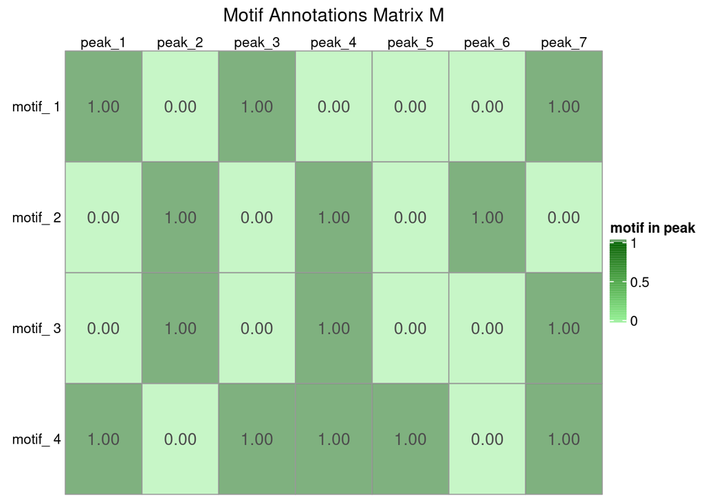

```r
# motif annotation matirix
m <- tibble::tribble(
  ~peak_1, ~peak_2, ~peak_3, ~peak_4, ~peak_5, ~peak_6, ~peak_7,
  1, 0, 1, 0, 0, 0, 1,
  0, 1, 0, 1, 0, 1, 0,
  0, 1, 0, 1, 0, 0, 1,
  1, 0, 1, 1, 1, 0, 1,
) %>%
  mutate(rownames = paste("motif_", 1:nrow(.))) %>%
  column_to_rownames(var = "rownames") %>%
  as.matrix()


p1 <- ComplexHeatmap::pheatmap(
   m,
   cluster_rows = F, cluster_cols = F,
   display_numbers = T,
   fontsize_number = 12,
   column_names_side = c("top"),
   row_names_side = c("left"),
   angle_col = c("0"),
   circlize::colorRamp2(c(0, max(m)), c("lightgreen", "darkgreen"), transparency = 0.5),
   column_title = "Motif Annotations Matrix M",
   heatmap_legend_param = list(title = "motif in peak")
   )
```

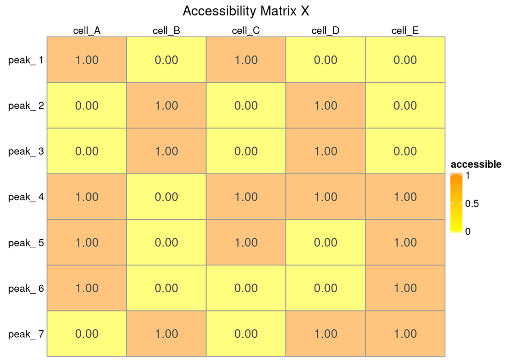

```r
# accessibility matrix
x <- tibble::tribble(
  ~cell_A, ~cell_B, ~cell_C, ~cell_D, ~cell_E,
  1, 0, 1, 0, 0,
  0, 1, 0, 1, 0,
  0, 1, 0, 1, 0,
  1, 0, 1, 1, 1,
  1, 0, 1, 0, 1,
  1, 0, 0, 0, 1,
  0, 1, 0, 1, 1
) %>%
  mutate(rownames = paste("peak_", 1:nrow(.))) %>%
  column_to_rownames(var = "rownames") %>%
  as.matrix()

p2 <- ComplexHeatmap::pheatmap(
   x,
   cluster_rows = F, cluster_cols = F,
   display_numbers = T,
   fontsize_number = 12,
   column_names_side = c("top"),
   row_names_side = c("left"),
   angle_col = c("0"),
   circlize::colorRamp2(c(0, max(x)), c("yellow", "darkorange"), transparency = 0.5),
   column_title = "Accessibility Matrix X",
   heatmap_legend_param = list(title = "accessible")
   )
```

```r
#gridExtra::grid.arrange(p1, p2, ncol = 2)

#ht_list <- p1 + p2
#draw(ht_list, ht_gap = unit(1, "cm"), show_heatmap_legend = FALSE)
```

```r
# comput expect

# define accessibility matrix
x =   matrix(c(1, 0, 1, 0, 0, 0, 1, 0, 1, 0,
  0, 1, 0, 1, 0,
  1, 0, 1, 1, 1,
  1, 0, 1, 0, 1,
  1, 0, 0, 0, 1,
  0, 1, 0, 1, 1), nrow = 7, ncol = 5)

# define motif match matrix
m = matrix(c(  1, 0, 1, 0, 0, 0, 1,
  0, 1, 0, 1, 0, 1, 0,
  0, 1, 0, 1, 0, 0, 1,
  1, 0, 1, 1, 1, 0, 1), ncol = 7, nrow = 4)


# compute elements for expect
# get the sum of reads for a peak j across all cells, length = number of peaks
total_read_per_peak = colSums(x)
# get the sum of reads for a cell i across all peaks, length = number of cells
total_read_per_cell = rowSums(x)
# get the total accessbility across all cells and peaks
total_reads = sum(x)


# computing expect
expect = outer(total_read_per_peak/total_reads, total_read_per_cell, "*")


# compute deviations
y = (m %*% x - m %*% t(expect)) / (m %*% t(expect))
```

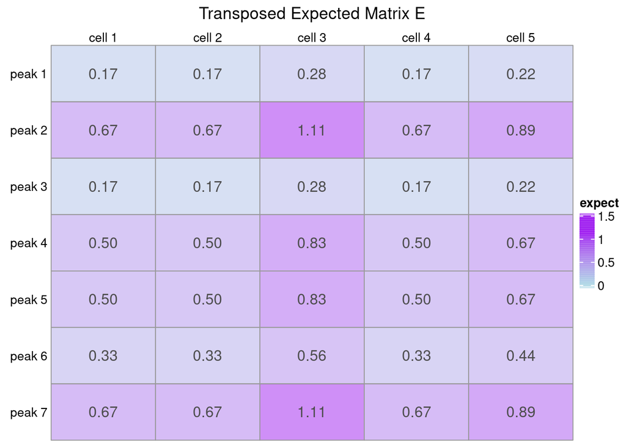

```r
expect_df <- as.data.frame(expect)
colnames(expect_df) = (paste("peak", 1:ncol(expect_df)))
rownames(expect_df) = paste("cell", 1:nrow(expect_df))

# p1 <- ComplexHeatmap::pheatmap(
#    expect_df,
#    cluster_rows = F, cluster_cols = F,
#    display_numbers = T,
#    fontsize_number = 12,
#    column_names_side = c("top"),
#    row_names_side = c("left"),
#    angle_col = c("0"),
#    circlize::colorRamp2(c(0, max(expect_df)), c("lightblue", "purple"), transparency = 0.5),
#    column_title = "Expected Matrix E",
#    heatmap_legend_param = list(title = "accessible")
#    )

p2 <- ComplexHeatmap::pheatmap(
   t(expect_df),
   cluster_rows = F, cluster_cols = F,
   display_numbers = T,
   fontsize_number = 12,
   column_names_side = c("top"),
   row_names_side = c("left"),
   angle_col = c("0"),
   circlize::colorRamp2(c(0, max(expect_df)), c("lightblue", "purple"), transparency = 0.5),
   column_title = "Transposed Expected Matrix E",
   heatmap_legend_param = list(title = "expect")
   )
```

[figure not shown]

```
proj <- loadArchRProject("12_Ricards_peaks_ChromVar/")
peaks <- getMatrixFromProject(proj, useMatrix = "PeakMatrix", binarize = TRUE)
peak_mat <- t(assays(peaks)[[1]]) # element of cells * peaks

# get the sum of reads for a peak j across all cells, length = number of peaks
total_read_per_peak = colSums(peak_mat)
# get the sum of reads for a cell i across all peaks, length = number of cells
total_read_per_cell = rowSums(peak_mat)
# get the total accessbility across all cells and peaks
total_reads = sum(peak_mat)

expect = total_read_per_peak/total_reads %o% t(total_read_per_cell)


expect = outer(total_read_per_peak[1:20]/total_reads, total_read_per_cell[1:10], "*")
```

```
library(reticulate)
```

```
import numpy as np
```

```r
deviations <- as.data.frame(y)
colnames(deviations) = (paste("cell_", 1:ncol(deviations)))
rownames(deviations) = paste("motif_", 1:nrow(deviations))


p2 <- ComplexHeatmap::pheatmap(
   deviations,
   cluster_rows = F, cluster_cols = F,
   display_numbers = T,
   fontsize_number = 12,
   column_names_side = c("top"),
   row_names_side = c("left"),
   angle_col = c("0"),
   circlize::colorRamp2(c(0, max(deviations)), c("yellow", "red"), transparency = 0.5),
   column_title = "Foreground deviations",
   heatmap_legend_param = list(title = "deviation")
   )
## Warning: The input is a data frame, convert it to the matrix.
```

## 2. Compute background accessibility deviations

Since we epect a bias in peaks depending on their GC content and average accessibility (due to Tn5 insertion bias) we want to correct this raw accessibility deviation which we computed above for the bias.

For this purpose, we smaple background peak sets for each motif. These background peak sets match the set of peaks with the motif annotations.

The background peakset $B \in \mathbb{R}^{J * J'}$ has entries $b_{jj'} = 1$ if peak $j$ has peak $j'$ as a background peak and $0$ otherwise. $MxB \in \mathbb{R}^{K*J'}$ contains motif matches for the background peaks $j'$.

$Y' = \frac{(MxB)x X^T - (MxB)xE^T}{M x E^T}$

The background deviations is computed for several iterations (50 by default) and then used to compute a bias-corrected deviation.

## 3. Compute bias-corrected deviations and z-scores

$Y - mean(Y') = Y - \frac{1}{N} \sum_{k = 1}{y_{ki}}$, with $N$ being the total number of cells.

Likewise we can now compute a bias-corrected z-score:

$\frac{Y - mean(Y')}{sd(Y')}$. This deviation z-score will be high if the difference in the number of fragmetns mapping to peaks with motif $k$ is high compared to the expected number of fragments mapping to a peak.

# Using motif annotations obtained from deep learning model

In this case we do not get a binary motif x peaks matrix $M$, but instead for each motif and peak a probability. Instead of a sum of reads mapping to a peak with motif $k$ we would then get a weighted sum of reads mapping to a peak with motif $k$. The rest of the computations stays the same.

Below is a visualization of this new matrix $M$:

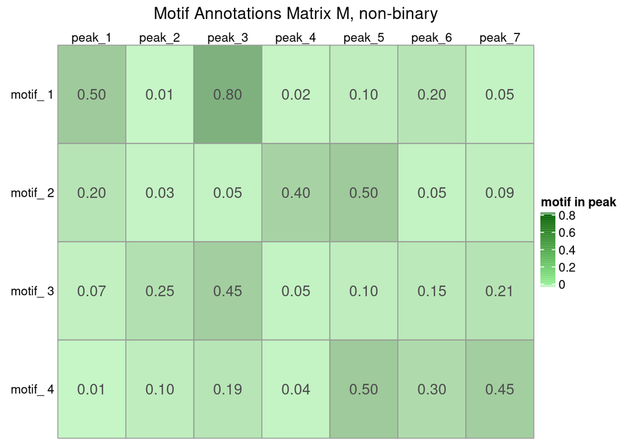

```r
# motif annotation matirix
m <- tibble::tribble(
  ~peak_1, ~peak_2, ~peak_3, ~peak_4, ~peak_5, ~peak_6, ~peak_7,
  0.5, 0.01, 0.8, 0.02, 0.1, 0.2, 0.05,
  0.2, 0.03, 0.05, 0.4, 0.5, 0.05, 0.09,
  0.07, 0.25, 0.45, 0.05, 0.1, 0.15, 0.21,
  0.01, 0.1, 0.19, 0.04, 0.5, 0.3, 0.45,
) %>%
  mutate(rownames = paste("motif_", 1:nrow(.))) %>%
  column_to_rownames(var = "rownames") %>%
  as.matrix()


p1 <- ComplexHeatmap::pheatmap(
   m,
   cluster_rows = F, cluster_cols = F,
   display_numbers = T,
   fontsize_number = 12,
   column_names_side = c("top"),
   row_names_side = c("left"),
   angle_col = c("0"),
   circlize::colorRamp2(c(0, max(m)), c("lightgreen", "darkgreen"), transparency = 0.5),
   column_title = "Motif Annotations Matrix M, non-binary",
   heatmap_legend_param = list(title = "motif in peak")
   )
```

# Plot TFs

## GATA Factors

```r
motifs <- c("Gata1", "Gata2", "Gata3", "Gata4", "Gata5", "Gata6")

markerMotifs <- getFeatures(proj, select = paste(motifs, collapse="|"),
                            useMatrix = "MotifMatrix", )
```

```
p <- plotEmbedding(
    ArchRProj = proj,
    colorBy = "MotifMatrix",
    name = sort(markerMotifs),
    embedding = "UMAP",
    imputeWeights = getImputeWeights(proj)
)
```

## Cardiomyocytes

```r
motifs <- c("Mef2c", "Mef2a", "Mef2d", "Mef2b", "Pknox2", "pknox1")

markerMotifs <- getFeatures(proj, select = paste(motifs, collapse="|"), useMatrix = "MotifMatrix")
```

```
p <- plotEmbedding(
    ArchRProj = proj,
    colorBy = "MotifMatrix",
    name = sort(markerMotifs),
    embedding = "UMAP",
    imputeWeights = getImputeWeights(proj)
)
```

## Gut

```r
motifs <- c("Id3", "Id4", "Tcf3", "Tcf4")

markerMotifs <- getFeatures(proj, select = paste(motifs, collapse="|"), useMatrix = "MotifMatrix")
```

```
p <- plotEmbedding(
    ArchRProj = proj,
    colorBy = "MotifMatrix",
    name = sort(markerMotifs),
    embedding = "UMAP",
    imputeWeights = getImputeWeights(proj)
)
```